# Practica de Laboratorio 3

## Nombre y Apellidos : José Santiago Sacón Yanchaguano

## Fecha : 18 de Noviembre de 2021

## Titulo

Practica acerca de Analisis Espectral - DTFT y DFT

## Tareas a relizar

**NOTA**: Para estas dos tareas, debera usted utilizar el archivo dsp.py y usar las funciones que vimos en la practica Sesion_3_Lab_DSP.

En otras palabras deberan invocar el archivo dsp.py como indica el siguiente ejemplo:

```python
import dsp as dsp
```

### 1. Analisis DTFT en secuencias

En esta tarea se le pide que use numpy (pylab o matplolib) para generar y graficar las secuencias que a continuación se presentan:

Utilizando la tecnica matricial vista en clase. Resolver lo siguiente: Aplique la DTFT X(ejω)en el rango −π ≤ ω ≤ π de las siguientes secuencias finitas. Dibuje la magnitud y fase de la DTFT usando dos subplots.

a) $x(n) = [u(n) − u(n − 25)]$ desde un rango $n=0,1,2,..99$.

```python
import numpy as np
import matplotlib.pyplot as p
N1=100
n1,y1=dsp.step(0,0,99)
n2,y2=dsp.step(25,0,99)
x1a=y1-y2
Y1=dsp.dft(x1a,N1)
mY1=np.abs(Y1)
m=n1
N=100
wm=2*np.pi/N * m
faseY1=np.angle(Y1) * 180/np.pi
```

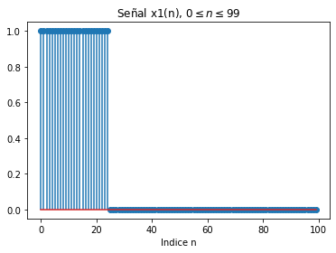

```python
p.stem(n1,x1a)
p.xlabel('Indice n')
p.title('Señal x1(n), $0 \leq n \leq 99$')
```

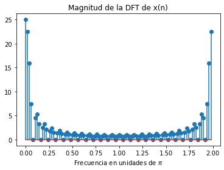

```python
p.stem(wm/np.pi, mY1)
p.xlabel('Frecuencia en unidades de $\pi$')
p.title('Magnitud de la DFT de x(n)')
```

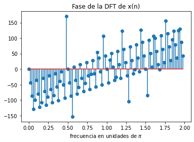

```python
p.stem(wm/np.pi, faseY1)
p.xlabel('frecuencia en unidades de $\pi$')
p.title('Fase de la DFT de x(n)')
```

b) $x(n) = [\cos(0.5 \pi n) + j \sin(0.5 \pi n)]$, donde $n=0..101$. Y si tenemos otra secuencia $y[n]=[u(n) − u(n − 51)]$ en el mismo rango de $n=0..101$. ahora sicreamos otra secuencia de tal forma que obtengamos $z[n]=x[n] \cdot y[n]$. Genere los graficos de magnitud espectral de $x[n]$, $y[n]$ y $z[n]$ usando subplots. Escriba comentarios acerca del grafico de magnitud.

```python
import math as m
Nb=102
nb=np.arange(0,103,1)
nb1,y1b=dsp.step(0,0,101)
nb2,y2b=dsp.step(51,0,101)
nb=nb1-nb2
xb=np.cos(0.5*np.pi*nb)+1j*np.sin(0.5*np.pi*nb)
z=nb*xb
Xb=dsp.dft(xb,Nb)
Nb=dsp.dft(nb,Nb)
Zb=dsp.dft(z,102)
mXb=np.abs(Xb)
mNb=np.abs(Nb)
mZb=np.abs(Zb)
m=len(nb)
wmb=2*np.pi/m*Nb
```

[figure not shown]

```python
p.stem(wmb/np.pi,mXb)
p.xlabel('Frecuencia en unidades de $\pi$')
p.title('Magnitud de la DFT de x(n)')
```

[figure not shown]

```python
p.stem(wmb/np.pi,mNb)
p.xlabel('Frecuencia en unidades de $\pi$')
p.title('Magnitud de la DFT de y(n)')
```

[figure not shown]

```python
p.stem(wmb/np.pi,mZb)
p.xlabel('Frecuencia en unidades de $\pi$')
p.title('Magnitud de la DFT de z(n)')
```

### 2. Aplicacion de las "ventanas" (Windowing) en la DFT

En este ejercicio y tomando como referencia la practica que conversamos sobre la transformada Discreta de Fourier - DFT.

Para ello pueden usar la funcion del archivo dsp.py de la siguiente forma:

```
Xw = dsp.dft(x,N)
```

Se tiene una señal analógica descrita como:

$$y(t) = A_1 \cos(2 \pi f t) + A_2 \cos(2 \pi (f + \Delta f)t) + A_3 \cos(2 \pi (f - \Delta f)t)$$

Donde $A_1=0.1$ y $A_2 = A_3=10$, la frecuencia $f=25$ y $\Delta f = 5$, la frecuencia de muestreo es de $f_s=100$.

1. Genere una senal discreta en el tiempo que inicie en el tiempo t=0, y que el numero total de muestras sea de N = 128. Determine para ello el tiempo final tomando en cuenta el tiempo de muestreo $t_s=1/f_s$. Una vez se tenga la senal discreta, obtenga las secuencias $x_t(n)=x(n)T(n)$ y $x_h(n)=x(n)H(n)$ donde $T(n)$ es la ventana triangular y $H(n)$ es la ventana Hanning. Grafique usando *subplot* las secuencias $x(n)$, $x_t(n)$ y $x_h(n)$.
2. Obtenga la magnitud de la DFT de las secuencias $x(n)$, $x_t(n)$ y $x_h(n)$. Haga comparaciones entre los tres resultados. Que puede concluir ante estas observaciones?

**Nota** para obtener las ventanas Triangular y Hanning usar la libreria Scipy.signal

```python
from scipy import signal
fs=100.
t=np.arange(0,2,1/fs)
f=25
delf=5
ts=1/fs
y2=(0.1*np.cos(2*np.pi*f*t))+(10*np.cos(2*np.pi*(f+delf)*t))+(10*np.cos(2*np.pi*(f-delf)*t))
N=y2.size
window=signal.triang(N)
y2w = window*y2
windowh=signal.windows.hann(N)
y2wh=windowh*y2
##DFT
Y2=dsp.dft(y2,N)
Y2W=dsp.dft(y2w,N)
Y2WH=dsp.dft(y2wh,N)
```

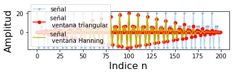

```python
p.subplot(3,1,1)
p.plot(np.arange(0,N,1),y2,'-o',label='señal',ms=3.,alpha=0.3)
p.plot(np.arange(0,N,1),y2w,'-or',label='señal \n ventana triangular',ms=5.)
p.plot(np.arange(0,N,1),y2wh,'-y',label='señal \n ventana Hanning',ms=5.)
p.ylabel('Amplitud',fontsize=16)
p.xlabel('Indice n',fontsize=16)
p.legend(loc=0)
```

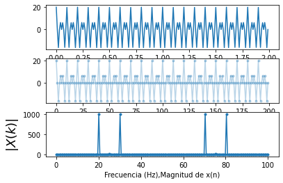

```python
p.subplot(3,1,1)
p.plot(t,y2)
p.xlabel('Tiempo (s)')
p.subplot(3,1,2)
p.plot(np.arange(0,N,1),y2,'-o',label='signal',ms=3.,alpha=0.3)
p.xlabel('Indice n')
p.subplot(3,1,3)
p.plot(np.linspace(0,fs,len(Y2)),np.abs(Y2),'-o',ms=3.)
p.ylabel(r'$|X(k)|$',fontsize=18)
p.xlabel('Frecuencia (Hz),Magnitud de x(n)')
```

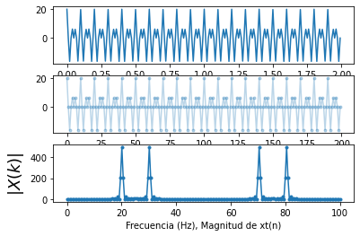

```python
p.subplot(3,1,1)
p.plot(t,y2)
p.xlabel('Tiempo (s)')
p.subplot(3,1,2)
p.plot(np.arange(0,N,1),y2,'-o',label='signal',ms=3.,alpha=0.3)
p.xlabel('Indice n')
p.subplot(3,1,3)
p.plot(np.linspace(0,fs,len(Y2W)),np.abs(Y2W),'-o',ms=3.)
p.ylabel(r'$|X(k)|$',fontsize=18)
p.xlabel('Frecuencia (Hz), Magnitud de xt(n)')
```

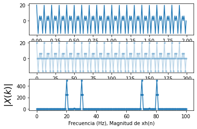

```python
p.subplot(3,1,1)
p.plot(t,y2)
p.xlabel('Tiempo (s)')
p.subplot(3,1,2)
p.plot(np.arange(0,N,1),y2,'-o',label='signal',ms=3.,alpha=0.3)
p.xlabel('Indice n')
p.subplot(3,1,3)
p.plot(np.linspace(0,fs,len(Y2WH)),np.abs(Y2WH),'-o',ms=3.)
p.ylabel(r'$|X(k)|$',fontsize=18)
p.xlabel('Frecuencia (Hz), Magnitud de xh(n)')
```

Las magnitudes de la DFT de las secuencias de ventanas son las mismas, posiblemente gracias a que restringen de algunas manera a la señal original. Como podemos observar, esta señal original tiene una amplitud mayor a la de las señales con la ventana.